# Basic Tutorial

https://macoskolab.github.io/liger/liger-vignette.html

## Data preprocessing

- ligerは、2つ以上のデジタル遺伝子発現(DGE)マトリックスのリストを入力として受け取ります。
- 遺伝子は行に、セルは列にあるべきである。
- factorizationを実行する前に、細胞ごとに異なる数のUMIを考慮してデータを正規化し、variable genesを選択し、データをスケールする必要があります。
- 非負値行列分解 (Nonnegative Matrix Factorization, NMF) は正の値しか受け付けないので、データを中心にしないことに注意してください。`selectGenes` 関数は、それぞれのデータセットに対して個別にvariable genesの選択を行い、それを統合します。
- 各データセットの同一遺伝子は同一の名前である必要があるが、遺伝子の順番は同じである必要はありません。
- cross-species analysisのためには、すべての遺伝子名を大文字に変換するのが便利かもしれません。

```r
#genes in rows, cells in columns, rownames and colnames included. Sparse matrix format is recommended.
dge1 = readRDS("dge1.RDS")
dge2 = readRDS("dge2.RDS")
ligerex = createLiger(list(name1 = dge1, name2 = dge2)) #Can also pass in more than 2 datasets
ligerex = normalize(ligerex)
ligerex = selectGenes(ligerex, var.thresh = 0.1)
ligerex = scaleNotCenter(ligerex)
```

[output not shown]

## Loading 10X Data

ligerには、10Xのcellrangerによって生成されたデータを読み取るための関数もあります。 複数のサンプル間でデータタイプ（最も一般的には遺伝子発現）ごとにデータをマージし、これを統合用の新しいオブジェクトの単一のデータセットとして使用できます。

```r
# 10X data to be combined for sample 1
sample1_data1 = "/path/to/10X/output/dir1"
sample1_data2 = "/path/to/10X/output/dir2"
sample1_dge = read10X(sample.dirs = list(sample1_data1, sample1_data2),
                      sample.names = c("s1_data1", "s1_data2"), min.umis = 500)
# 10X data for sample 2
sample2_data = "/path/to/10X/output/dir3"
sample2_dge = read10X(sample.dirs = list(sample2_data),
                      sample.names = c("s2_data"), min.umis = 500)
liger10X = createLiger(list(sample1 = sample1_dge, sample2 = sample2_dge))
# continue with other preprocessing steps
```

## Performing the factorization

- 次に、交互最小二乗アルゴリズム(alternating least squares algorithm)を用いてfactorizationを実行する。
- factorizationを実行した後、対応する細胞因子に重みのある細胞を特定し、データセット全体でその因子負荷 (factor loadings)を正規化する。
- ここでの重要なパラメータは、因子の数(k)、ペナルティ・パラメータ(lambda)、クラスタリングの解像度である。
- ほとんどの場合、lambda=5.0、resolution=1.0のデフォルト設定で妥当な結果が得られます。

```r
ligerex = optimizeALS(ligerex, k = 20)
ligerex = quantileAlignSNF(ligerex) #SNF clustering and quantile alignment
```

## Visualizing the results

t-SNEやUMAPのような次元削減技術を使用して結果を可視化することができます（大規模なデータセットには推奨されます）。 可視化は、sample ID、クラスタ、セルのメタデータ（`cell.data`）に含まれている任意の特徴によって色分けすることができます。

`plotWordClouds`と`plotGeneLoadings`は、各因子に対して最も重みのある遺伝子（共有およびデータセット固有の両方）を、細胞間の因子負荷量と合わせて可視化するのに便利な方法です。 これらの関数は非常に似ていますが、 `plotGeneLoadings` は、ワードクラウドの代わりに、top loading genesを順序付き散布図で表示します。

```r
ligerex = runTSNE(ligerex)
# for larger datasets, may want to use UMAP instead
ligerex = runUMAP(ligerex)
plotByDatasetAndCluster(ligerex) #Can also pass in different set of cluster labels to plot
plotFeature(ligerex, "nUMI")
pdf("word_clouds.pdf")
plotWordClouds(ligerex)
dev.off()
pdf("gene_loadings.pdf")
plotGeneLoadings(ligerex)
dev.off()
```

## Exploring factors and clusters

細胞間の因子負荷を調べたり、アラインメントプロセスを可視化したりするためのもう一つの方法は `plotFactors` です。 また、`plotClusterProportions`と`plotClusterFactors`を用いて、データ内のクラスタと因子の対応関係を可視化することもできます。 これらは、特定の因子やそれに対応するマーカー遺伝子に関連するクラスタを特定するのに特に有用です。

```r
plotFactors(ligerex)
plotClusterProportions(ligerex)
plotClusterFactors(ligerex, use.aligned = T)
```

## Finding and visualizing marker genes

- factorization を利用して，共有マーカとデータセット固有のマーカをより明確に識別することができます．
- `getFactorMarkers`関数はリストを返します。
  - 最初の要素はデータセット1のデータセット固有のマーカー、
  - 2番目の要素は共有マーカー、
  - 3番目の要素はデータセット2のデータセット固有のマーカー、
  - 最後の2つの要素は各マーカーが見つかった因子の数を示します。
- この情報により、ユビキタスと細胞型特異的なデータセットの違いを識別することができる。

```r
markers = getFactorMarkers(ligerex, num.genes = 10)
plotGene(ligerex, gene = "Malat1")
plotGeneViolin(ligerex, gene = "Malat1")
```

## Comparing different cluster assignments

既存のクラスタリングとligerのクラスタリング結果比較し、可視化することができます（個々のデータセットでクラスタ割り当てが利用可能な場合）。

```r
# published cluster assignments for all cells in dataset 1 and 2
clusters_published1 = readRDS("clusters1.RDS")
clusters_published2 = readRDS("clusters2.RDS")
# calculate adjusted Rand Index between liger cluster assignments and another assignment
calcARI(ligerex, c(clusters_published1, clusters_published2))
# calculate purity between liger cluster assignments and another assignment for just dataset 1
calcPurity(ligerex, clusters_published1)
# visualize joint cluster assignment as related to individual dataset cluster assignments
makeRiverplot(ligerex, clusters_published1, clusters_published2)
```

## Checking dataset alignment and individual dataset distortion

ligerには，factorization とアラインメントの後の（その前と比較して）個々のデータセットのデータセット間の統合度（整列度）と構造の歪み度を推定する方法が含まれている． 一般に、意味のある方法でfactorization とアラインメントが行われたデータセットは、歪みの程度が低い（high agreement metric）を維持しつつ、高い統合度（high alignment metric）を示すべきである。

```r
calcAlignment(ligerex)
calcAgreement(ligerex)
# see if certain clusters are more integrated than others
calcAlignmentPerCluster(ligerex)
```

## Selecting k and lambda

- `suggestK`と `suggestLambda`関数は、kとλを選択するのに役立ちます。
- やりたいことは、エントロピーメトリックの増加が平準化し始める（プロットでは "エルボー "となります）最小のkを見つけることです。
- 同様に、アライメントメトリックが安定する最小のλを求めます。

```r
# plot entropy metric to find an elbow that can be used to select the number of factors
suggestK(ligerex)
# plot alignment metric to find an elbow that can be used to select the value of lambda
suggestLambda(ligerex, k)
```

## Updating the factorization

新しいデータを追加したり、kやラムダを変更したり、データのサブセットを再解析したりしたい場合、以下の関数を使用すると効率的な更新方法が得られます。これは、単に`optimizeALS`アルゴリズムを再実行するというナイーブなアプローチよりもはるかに高速です。

```r
ligerex = optimizeNewK(ligerex, k = 15) #Can also decrease K
#Add new batches from the same condition/technology/species/protocol
ligerex = optimizeNewData(ligerex, newdata = list(name1 = dge1.new, name2 = dge2.new),
                          which.datasets = list(name1, name2), add.to.existing = T)
#Add completely new datasets. Specify which existing datasets are most similar.
ligerex = optimizeNewData(ligerex, newdata = list(name3 = dge3, name4 = dge4),
                          which.datasets = list(name1, name2), add.to.existing = F)
#cell.subset is a list of cells to retain from each dataset
ligerex = optimizeSubset(ligerex, cell.subset)
```

## Integration between liger and Seurat

We can easily create liger objects from Seurat (V2 or V3) objects (and vice versa), while keeping calculated features from the original objects.

```r
# Create liger object from two separate Seurat objects, keeping union of top 2000 highly variable
# genes from each object
ligerex = seuratToLiger(list(seurat1, seurat2), names = c('name1', 'name2'), num.hvg.info = 2000)
# Create liger object from single integrated Seurat V2 object, keeping CCA factorization,
# splitting datasets by Seurat meta.var column "original"
ligerex = seuratToLiger(seurat_obj, combined.seurat = T, meta.var = 'original', cca.to.H = T)
# Create liger object from single integrated Seurat V3 object, splitting datasets by two
# available assays in Seurat
ligerex = seuratToLiger(seurat_obj, combined.seurat = T, assays.use = c('RNA', 'ADT'))
# Create Seurat object from liger object, keeping liger highly variable genes
seurat_obj = ligerToSeurat(ligerex, use.liger.genes = T)
```

# Walkthorough

https://macoskolab.github.io/liger/walkthrough_pbmc.html

- このウォークスルーでは、10Xおよび[Gierahn et al., 2017](https://www.ncbi.nlm.nih.gov/pmc/articles/PMC5376227/) から提供された末梢血単核球（PBMCs）の2つのデータセットの基本的な分析とアラインメントを順を追って説明します。
- データセット固有の違いに加えて、両方のデータセット間の傾向やクラスタを識別するためにLIGERがどのように使用できるかを示します。
- また、論文の図の一部を再現しながら、パッケージの可視化機能の一部を実証しています（図2）。

```r
# Download data
system("wget https://macoskolab.github.io/liger/pbmc_alignment.zip")
system("unzip pbmc_alignment.zip && rm pbmc_alignment.zip")
```

```r
options(warn=-1)
library(liger)
library(cowplot)
```

```r
pbmc.10x <- read.table('pbmc_alignment/pbmc_10X.expressionMatrix.txt',
                       sep="\t",
                       stringsAsFactors=F,
                       header=T,
                       row.names = 1)
pbmc.seqwell <- read.table('pbmc_alignment/pbmc_SeqWell.expressionMatrix.txt',
                           sep="\t",
                           stringsAsFactors=F,
                           header=T,
                           row.names = 1)
pbmc.data = list(tenx=pbmc.10x, seqwell=pbmc.seqwell)

# Create liger object
a.pbmc <- createLiger(pbmc.data)
```

```
[1] "Removing 16159 genes not expressing in tenx."
```

## Data Preprocessing

- Factorizaionを実行する前に、細胞間のsequencing depthやキャプチャー効率の違いを考慮してデータを正規化し、variable genesを選択し、データをスケーリングする必要があります。
- NMFは非負の値しか受け付けないので、スケーリングの際にデータをセンタリングしないことに注意してください。
- `selectGenes` 関数は、それぞれのデータセットに対して個別に可変遺伝子の選択を行い、その結果の和を取ります。
- Highly variable genesは，各遺伝子の発現の分散と平均発現を比較して，指定されたしきい値以上の比率を持つものを保持することで選択されます．
- また、事前に選択されたvariable genesを単にオブジェクトに渡すこともできます。
- ここでは、Seuratパッケージによって決定されたvariable genesを使用して2つのデータセットを解析そます（これは、方法のよりクリーンな比較のために論文中で行われました）。

```r
a.pbmc <- normalize(a.pbmc)
# Can pass different var.thresh values to each dataset if one seems to be contributing significantly
# more genes than the other
a.pbmc <- selectGenes(a.pbmc, var.thresh = c(0.3, 0.875), do.plot = F)

# In this case, we have a precomputed set of variable genes
s.var.genes <- readRDS('pbmc_alignment/var_genes.RDS')
a.pbmc@var.genes <- s.var.genes
a.pbmc <- scaleNotCenter(a.pbmc)
```

## Factorizaion

- 次に、データセット間で共有されているmetagenes を識別するために、統合的なNMFを実行し、各細胞の対応する 因子およびmetagenesの負荷量を特定する。
- Factorizaionで最も重要なパラメータは、k（因子の数）とλ（Factorizaionのデータセット固有の成分を制限するペナルティパラメータ）です。
- デフォルト値のlambda=5.0は、通常、ほとんどの解析で妥当な結果を提供しますが、 `suggestLambda`関数を使用して、データセットのアラインメントを希望するレベルに応じて、より適切なlambda値を決定することができます。
- 使用する因子の適切な数を決定するために、因子負荷量の一様分布からのK-L発散の中央値をkの関数としてプロットする `suggestK`関数を使用することができます。一般的に、分析で見つけると予想されるサブグループの数と使用する適切な因子の数との間に正の相関があることを期待するべきです。
- `suggestK`関数の実行には10分以上かかることがあるので、より高い数の因子が必要かどうかのアイデアを得るために、k=20で素早く予備分析を実行することが有用な場合があります。

```r
# running suggestK on multiple cores can greatly decrease the runtime
k.suggest <- suggestK(a.pbmc,
                      num.cores = 24,
                      gen.new = T,
                      plot.log2 = F,
                      # , return.results = T
                      nrep = 5)
```

```
[1] "This operation may take several minutes depending on number of values being tested"
[1] "Preprocessing for rep 1: optimizing initial factorization with largest test k=50"
Finished in 3.680157 mins, 27 iterations.
Max iterations set: 100.
Final objective delta: 8.853453e-05.
Best results with seed 1.
[1] "Progress now represents completed factorizations (out of total number of k values)"
[1] "Preprocessing for rep 2: optimizing initial factorization with largest test k=50"
Finished in 3.110598 mins, 22 iterations.
Max iterations set: 100.
Final objective delta: 9.698866e-05.
Best results with seed 2.
[1] "Progress now represents completed factorizations (out of total number of k values)"
[1] "Preprocessing for rep 3: optimizing initial factorization with largest test k=50"
Finished in 3.890149 mins, 22 iterations.
Max iterations set: 100.
Final objective delta: 9.640452e-05.
Best results with seed 3.
[1] "Progress now represents completed factorizations (out of total number of k values)"
[1] "Preprocessing for rep 4: optimizing initial factorization with largest test k=50"
Finished in 3.19393 mins, 23 iterations.
Max iterations set: 100.
Final objective delta: 9.243777e-05.
Best results with seed 4.
[1] "Progress now represents completed factorizations (out of total number of k values)"
[1] "Preprocessing for rep 5: optimizing initial factorization with largest test k=50"
Finished in 2.976178 mins, 21 iterations.
Max iterations set: 100.
Final objective delta: 9.419026e-05.
Best results with seed 5.
[1] "Progress now represents completed factorizations (out of total number of k values)"

Completed in: 37.337702135245 mins
```

- 以下の解析では、kを22に設定していますが、同様の結果を得るために、似たような結果を返す範囲内で様々な値を試すことができます。
- デフォルトの`lambda=5.0`を選択します。（与えられた因子数に対する期待されるアライメントとlambdaのプロットを得るために `suggestLambda`を実行することもできます）。

```r
# Take the lowest objective of three factorizations with different initializations
# Multiple restarts are recommended for initial analyses since iNMF is non-deterministic
a.pbmc <- optimizeALS(a.pbmc, k=22, thresh = 5e-5, nrep = 3)
```

```
Finished in 2.436064 mins, 18 iterations.
Max iterations set: 30.
Final objective delta: 3.663511e-05.
Finished in 2.858197 mins, 21 iterations.
Max iterations set: 30.
Final objective delta: 3.582454e-05.
Finished in 3.059642 mins, 27 iterations.
Max iterations set: 30.
Final objective delta: 4.398267e-05.
Best results with seed 3.
```

- Factorizaionを行った後も、データセット間の因子負荷 (factor loadings)をquantileで揃える必要があります。
- 因子負荷量のt-SNE表現をプロットすると、データはまだ主にデータセットごとにクラスタ化されていることに注目してください。

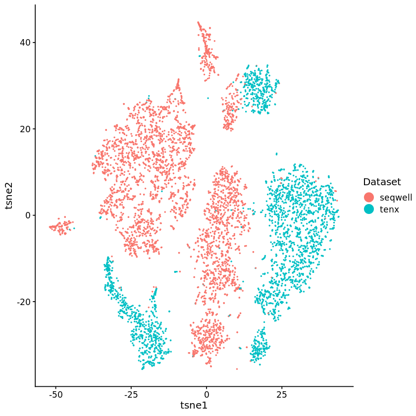

```r
a.pbmc <- runTSNE(a.pbmc, use.raw = T)
p1 <- plotByDatasetAndCluster(a.pbmc, return.plots = T)
# Plot by dataset
print(p1[[1]])
```

- データセットをより良く統合するためにquantileアライメントを実行する。
- このプロセスでは、まず、共有された因子の近傍 (shared factor neighborhoods)に基づいてsimilarity グラフを構築することで、データセット間で類似した負荷を持つ細胞を識別します。
- 次に、Louvain のコミュニティ検出を使用してデータセット間で共有されているクラスタを特定し、各クラスタと因子内のquantiles を揃えます。
- このステップで重要なパラメータは、`resolution`（これを上げると検出されるコミュニティの数が増えます）と`knn_k`（共有因子近傍を生成する際に使用されるデータセット近傍の数）です。
  - 一般的に，`knn_k`を小さくすると，共有因子近傍を持つより小さなグループをより細かく識別することができるようになります．
- また、`small_clust_thresh` パラメータを現在の `knn_k` と同じに設定することで、さらに小さなクラスタを抽出することもできます。より大きなクラスタを識別するために`resolution`を0.4に設定し、他のパラメータはデフォルトの設定を使用します。
- (より簡単な解析を行い、原稿の図を完全に再現するために、デフォルトの`small.clust.thresh = 0`を使用することができますが、これはmegakaryocytesの分離を妨げることになります)。

```r
a.pbmc <- quantileAlignSNF(a.pbmc, resolution = 0.4, small.clust.thresh = 20)
# Could also forgo small cluster extraction if desired
# a.pbmc <- quantileAlignSNF(a.pbmc, resolution = 0.4)
```

## Visualization

```r
a.pbmc <- runTSNE(a.pbmc)
```

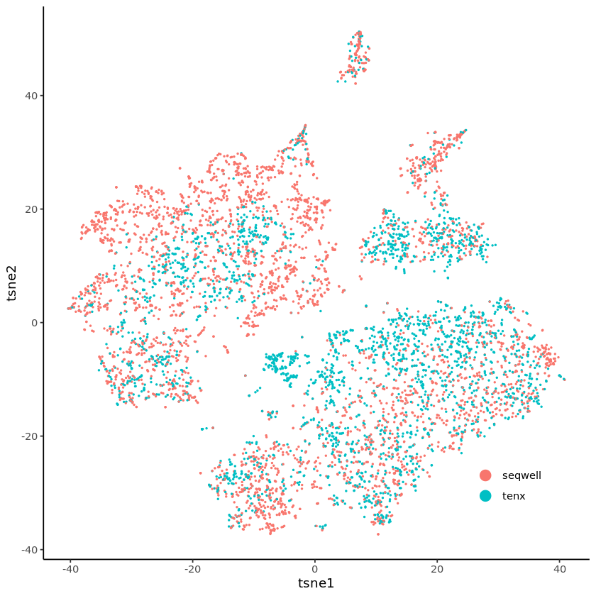

```r
library(ggplot2)
p_a <- plotByDatasetAndCluster(a.pbmc, return.plots = T)
# Modify plot output slightly
p_a[[1]] <- p_a[[1]] + theme_classic() + theme(legend.position = c(0.85, 0.15)) +
  guides(col=guide_legend(title = '', override.aes = list(size = 4)))

print(p_a[[1]])
```

- これら2つのデータセットのそれぞれについて、オリジナルの論文や解析結果からクラスター情報が得られているので、river （すなわちSankey）プロットを用いて、我々のクラスタリングがどのように比較されているかを簡単に見ることができます。
- これらのクラスタリングは、各データセットの個別の（共同ではない）分析によって生成されたものであることに注意してください。10Xラベルは、ここに詳細が記載されているSeurat解析と、オリジナルのSeqWell出版物のSeqWellラベルに由来しています。

```r
# load cluster labels from Seurat 10X PBMC analysis and original SeqWell publication
clusters_prior <- readRDS('pbmc_alignment/tenx_seqwell_clusters.RDS')
tenx_c <- droplevels(clusters_prior[rownames(a.pbmc@H[[1]])])
seqwell_c <- droplevels(clusters_prior[rownames(a.pbmc@H[[2]])])

# Set specific node order for cleaner visualization (can also leave to default value for
# automatic ordering)
set_node_order = list(c(2, 6, 3, 4, 8, 1, 5, 7), c(1, 6, 2, 3, 4, 5, 7, 8, 9), c(5, 2, 3, 6, 1, 4))
makeRiverplot(a.pbmc, tenx_c, seqwell_c, min.frac = 0.05, node.order = set_node_order,
              river.usr = c(0, 1, -0.6, 1.6))
```

[output not shown]

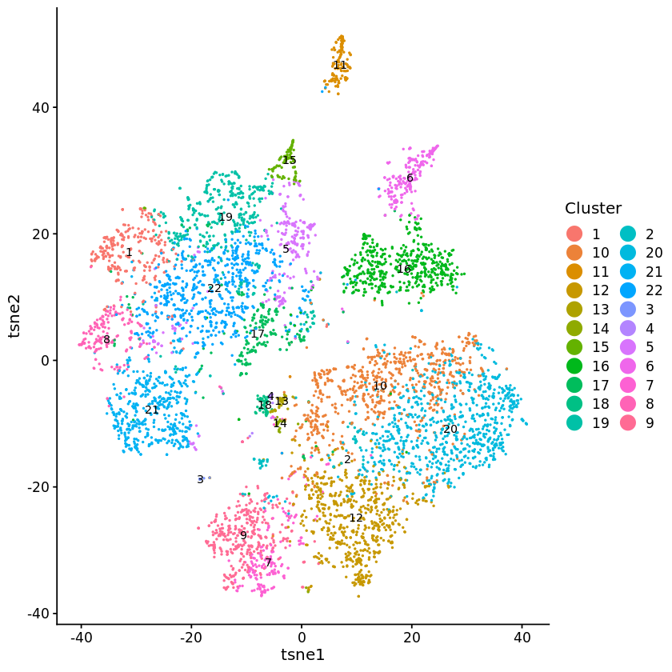

```r
# If using object with default small.clust.thresh settings, use this node order instead
# set_node_order = list(c(7, 2, 6, 3, 4, 8, 1, 5), c(1, 6, 2, 3, 4, 5, 7, 8), rev(c(4, 1, 6, 3, 2, 5)))

# plot t-SNE plot colored by clusters
print(p_a[[2]])
```

また、各因子の共有マーカーやデータセット固有のマーカーを特定し、それらをプロットすることで、クラスタアノテーションに役立てることができます。この情報は、細胞タイプ特有のデータセットの違いを見つけるのに役立ちます。これは `getFactorMarkers` 関数を使ってテーブル形式で得ることができますが、これらのマーカー（および因子負荷の分布）を可視化する簡単な方法は、パッケージの`plotWordClouds`関数を使うことです。ここでは、NK細胞クラスタに対応していると思われる因子9のプロットにおいて、最も負荷の高いデータセット特異的なマーカーの一つがCD16 (FCGR3A)であることに気づくことができます。

```r
# This function uses the V loadings to identify dataset-specific genes and a combination of the W
# and V loadings to identify shared markers
markers <- getFactorMarkers(a.pbmc, dataset1='tenx', dataset2='seqwell', num.genes = 10)
# The first three elements in this list are the dataset1-specific, shared, and dataset2-specific
# markers respectively
# Let's take a look at factor 9
head(markers$tenx[markers$tenx$factor_num == 9, ])
```

A data.frame: 6 × 8

|  | factor_num <dbl> | gene <chr> | counts1 <dbl> | counts2 <dbl> | fracs1 <dbl> | fracs2 <dbl> | log2fc <dbl> | p_value <dbl> |
| --- | --- | --- | --- | --- | --- | --- | --- | --- |
| FCGR3A | 9 | FCGR3A | 311 | 270.2475 | 0.8253968 | 0.17889908 | 3.369360 | 8.306949e-37 |
| RAMP1 | 9 | RAMP1 | 38 | 105.1376 | 0.2301587 | 0.06422018 | 1.739324 | 1.043517e-05 |
| CD63 | 9 | CD63 | 227 | 850.0802 | 0.7222222 | 0.43119266 | 1.239062 | 2.896254e-10 |
| CCL4 | 9 | CCL4 | 486 | 950.6504 | 0.6904762 | 0.31192661 | 2.195697 | 2.117245e-14 |
| LAMP1 | 9 | LAMP1 | 76 | 286.2575 | 0.4523810 | 0.17889908 | 1.282764 | 8.163031e-08 |
| ITGB2 | 9 | ITGB2 | 278 | 712.4125 | 0.8253968 | 0.36697248 | 1.793409 | 2.078076e-19 |

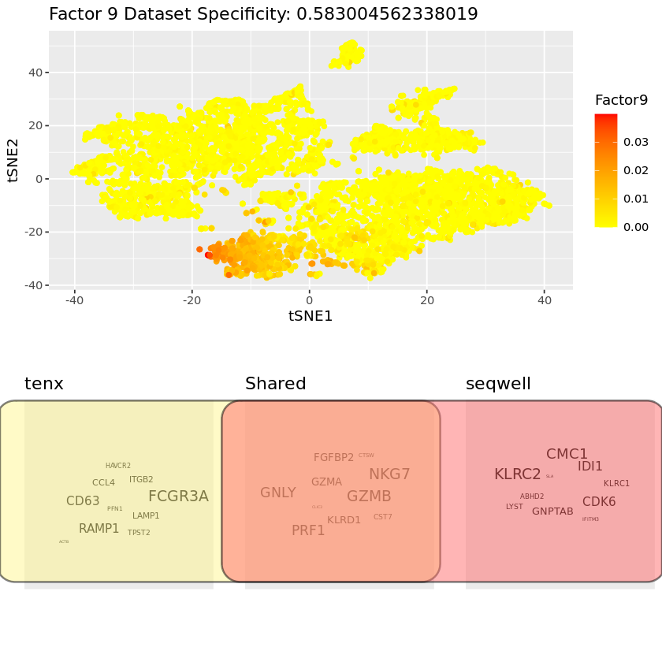

```r
# Show top 10 highly loading dataset specific and shared genes
# Prevent text progress bar from printing
word_clouds <- plotWordClouds(a.pbmc, num.genes = 10, do.spec.plot = F, return.plots = T)
print(word_clouds[[9]])
```

関連するタイプの可視化は「遺伝子負荷プロット」です。これは最も負荷の高い遺伝子の比較を容易にするでしょう。

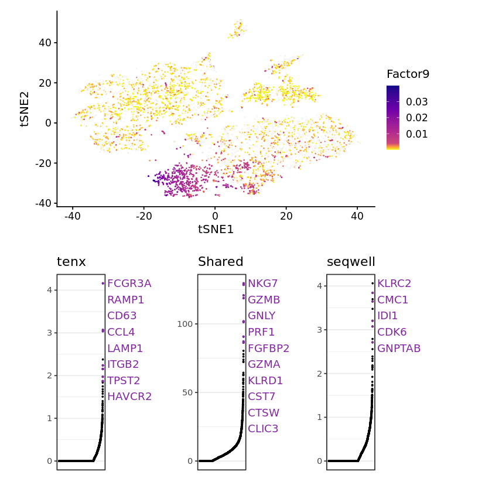

```r
# Show top 10 highly loading dataset specific and shared genes
# with plots of gene loading values
gene_loadings <- plotGeneLoadings(a.pbmc, num.genes = 10, do.spec.plot = F, return.plots = T)
print(gene_loadings[[9]])
```

この遺伝子をプロットすることで、より詳細なデータセット固有の違いをよりよく観察することができるようになりました。

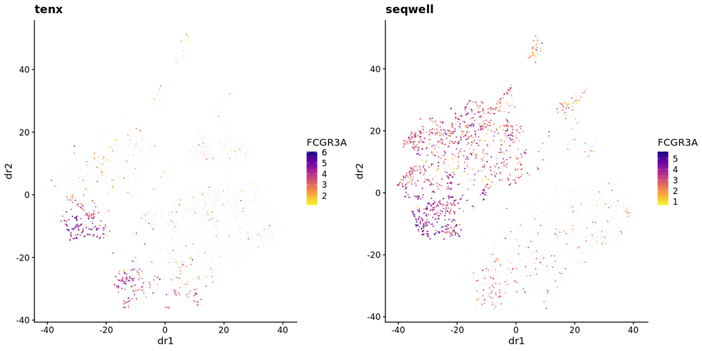

```r
options(repr.plot.width=12, repr.plot.height=6)
p_g2 <- plotGene(a.pbmc, 'FCGR3A', return.plots = T)
plot_grid(plotlist = p_g2)
```

これらのプロットで、seqwellデータセットのNKクラスタは、10XデータセットのものほどCD16を発現していないようです（予想通り、多くのミエロイド細胞がこのマーカーを発現していますが）。これは、10X患者のサイトカイン活性化の追加を示唆しているかもしれません。